# R Notebook

```r
resettest(salfit, power = 2:3, type="regressor")
```

```
    RESET test

data:  salfit
RESET = 0.26893, df1 = 4, df2 = 41, p-value = 0.8963
```

```r
ncvTest(salfit)
```

```
Non-constant Variance Score Test
Variance formula: ~ fitted.values
Chisquare = 6.427247, Df = 1, p = 0.011238
```

```r
bptest(salfit)
```

```
    studentized Breusch-Pagan test

data:  salfit
BP = 5.9028, df = 6, p-value = 0.4342
```

```r
vif(salfit)
```

```
           GVIF Df GVIF^(1/(2*Df))
sex    1.523618  1        1.234349
degree 2.123396  1        1.457188
rank   3.751805  2        1.391746
year   2.422657  1        1.556489
ysdeg  5.562508  1        2.358497
```

Something new that we are introducing in our diagnostics is the variable inflation factor to detect any multicollinearity. The only one that we see that may cause issues is ysdeg(years since degree) which is already an insignificant variable.

```r
outlierTest(salfit)
```

|  | rstudent | unadjusted p-value | Bonferroni p |
| --- | --- | --- | --- |
| 24 | 5.120436 | 6.4712e-06 | 0.0003365 |

Finally, we are going to do the same model, but this time without rank. Although rank was considered significant within levels, we just want to do this in order to use the ANOVA to compare our two models.

```r
salfit2 <- lm(salary~degree+sex+year+ysdeg, data=salary)
summary(salfit2)
```

```
Call:
lm(formula = salary ~ degree + sex + year + ysdeg, data = salary)

Residuals:
    Min      1Q  Median      3Q     Max
-8146.9 -2186.9  -491.5  2279.1 11186.6

Coefficients:
            Estimate Std. Error t value Pr(>|t|)
(Intercept) 17183.57    1147.94  14.969  < 2e-16 ***
degreePhD   -3299.35    1302.52  -2.533 0.014704 *
sexFemale   -1286.54    1313.09  -0.980 0.332209
year          351.97     142.48   2.470 0.017185 *
ysdeg         339.40      80.62   4.210 0.000114 ***
---
Signif. codes:  0 ‘***’ 0.001 ‘**’ 0.01 ‘*’ 0.05 ‘.’ 0.1 ‘ ’ 1

Residual standard error: 3744 on 47 degrees of freedom
Multiple R-squared:  0.6312,    Adjusted R-squared:  0.5998
F-statistic: 20.11 on 4 and 47 DF,  p-value: 1.048e-09
```

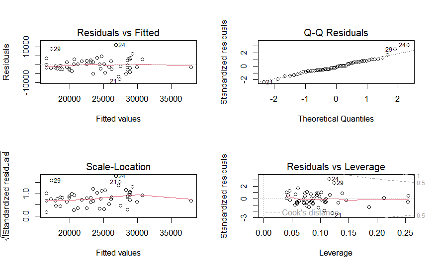

```r
par(mfrow=c(2,2))
plot(salfit2)
```

```
           Test stat Pr(>|Test stat|)
degree
sex
year         -0.3482          0.72931
ysdeg        -1.9542          0.05677 .
Tukey test   -0.1340          0.89343
---
Signif. codes:  0 ‘***’ 0.001 ‘**’ 0.01 ‘*’ 0.05 ‘.’ 0.1 ‘ ’ 1
```

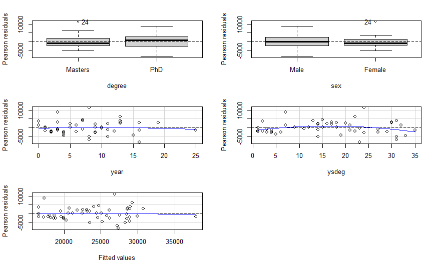

```r
residualPlots(salfit2)
```

```r
resettest(salfit2, power = 2:3, type = "regressor")
```

```
    RESET test

data:  salfit2
RESET = 1.3182, df1 = 4, df2 = 43, p-value = 0.2785
```

```r
ncvTest(salfit2)
```

```
Non-constant Variance Score Test
Variance formula: ~ fitted.values
Chisquare = 1.312735, Df = 1, p = 0.2519
```

```r
bptest(salfit2)
```

```
    studentized Breusch-Pagan test

data:  salfit2
BP = 2.4306, df = 4, p-value = 0.6571
```

```r
vif(salfit2)
```

```
  degree      sex     year    ysdeg
1.424821 1.258752 2.241000 2.471785
```

```r
outlierTest(salfit2)
```

|  | rstudent | unadjusted p-value | Bonferroni p |
| --- | --- | --- | --- |
| 24 | 3.547861 | 0.00090695 | 0.047162 |

```r
anova(salfit)
```

```
Analysis of Variance Table

Response: salary
          Df     Sum Sq   Mean Sq  F value    Pr(>F)
sex        1  114106220 114106220  19.8363 5.527e-05 ***
degree     1    4533026   4533026   0.7880    0.3794
rank       2 1246074941 623037470 108.3090 < 2.2e-16 ***
year       1  147289148 147289148  25.6048 7.528e-06 ***
ysdeg      1   14868158  14868158   2.5847    0.1149
Residuals 45  258858365   5752408
---
Signif. codes:  0 ‘***’ 0.001 ‘**’ 0.01 ‘*’ 0.05 ‘.’ 0.1 ‘ ’ 1
```

```r
anova(salfit2, salfit)
```

```
Analysis of Variance Table

Model 1: salary ~ degree + sex + year + ysdeg
Model 2: salary ~ sex + degree + rank + year + ysdeg
  Res.Df       RSS Df Sum of Sq     F    Pr(>F)
1     47 658649047
2     45 258858365  2 399790682 34.75 7.485e-10 ***
---
Signif. codes:  0 ‘***’ 0.001 ‘**’ 0.01 ‘*’ 0.05 ‘.’ 0.1 ‘ ’ 1
```

Our next problem we are going to look at the strength of wool in a manufacturing setting based on the length of the yarn, the amount the yarn was asked to hold and the time the yarn was asked to hold per cycle. We will be looking a the wool data set from the alr4 package.

```r
head(Wool)
```

|  | len | amp | load | cycles |
| --- | --- | --- | --- | --- |
| 1 | 250 | 8 | 40 | 674 |
| 2 | 250 | 8 | 45 | 370 |
| 3 | 250 | 8 | 50 | 292 |
| 4 | 250 | 9 | 40 | 338 |
| 5 | 250 | 9 | 45 | 266 |
| 6 | 250 | 9 | 50 | 210 |

```r
summary(Wool)
```

```
      len           amp          load        cycles
 Min.   :250   Min.   : 8   Min.   :40   Min.   :  90.0
 1st Qu.:250   1st Qu.: 8   1st Qu.:40   1st Qu.: 312.0
 Median :300   Median : 9   Median :45   Median : 566.0
 Mean   :300   Mean   : 9   Mean   :45   Mean   : 861.4
 3rd Qu.:350   3rd Qu.:10   3rd Qu.:50   3rd Qu.:1105.0
 Max.   :350   Max.   :10   Max.   :50   Max.   :3636.0
```

```r
unique(Wool$load)
```

```
[1] 40 45 50
```

Looking at this data, we are dealing with mostly continous data. For our purpose, we want to turn the load variable into a factor with three levels. We will use all the other variables as predictors with cycles as the response.

```r
woolfit <- lm(cycles~len+amp+as.factor(load), data=Wool)
summary(woolfit)
```

```
Call:
lm(formula = cycles ~ len + amp + as.factor(load), data = Wool)

Residuals:
   Min     1Q Median     3Q    Max
-628.4 -275.8 -134.1  215.6 1284.1

Coefficients:
                  Estimate Std. Error t value Pr(>|t|)
(Intercept)        2018.61    1281.70   1.575 0.129539
len                  13.20       2.35   5.617  1.2e-05 ***
amp                -535.83     117.49  -4.561 0.000153 ***
as.factor(load)45  -262.56     234.99  -1.117 0.275909
as.factor(load)50  -621.67     234.99  -2.646 0.014772 *
---
Signif. codes:  0 ‘***’ 0.001 ‘**’ 0.01 ‘*’ 0.05 ‘.’ 0.1 ‘ ’ 1

Residual standard error: 498.5 on 22 degrees of freedom
Multiple R-squared:  0.7298,    Adjusted R-squared:  0.6806
F-statistic: 14.85 on 4 and 22 DF,  p-value: 5.068e-06
```